# STATS786 Group Project

Group 4: Joshua Buchanan, Bea Cooke, Xinyi Kong, Marlon Chhour

03 June 2026

```r
library(tidyverse)
library(fpp3)
library(tsibble)
library(feasts)
library(fable)
library(lubridate)
library(here)
library(urca)
library(imputeTS)
library(patchwork)
library(magrittr)
library(janitor)
```

# 1 Data Cleaning and Exploratory Data Analysis

## 1.1 Data Description

Contributors: Joshua Buchanan

```r
# Load data
nelson <- read_csv('nelson.csv')
glimpse(nelson)
```

```
## Rows: 993
## Columns: 3
## $ Month       <chr> "April", "May", "June", "July", "August", "September", "Oc…
## $ Year        <dbl> 1943, 1943, 1943, 1943, 1943, 1943, 1943, 1943, 1943, 1944…
## $ Temperature <dbl> 12.1, 8.4, 7.3, 5.8, 5.7, 9.9, 11.1, 13.7, 16.0, 17.8, 16.…
```

## 1.2 Train / Test Split

Contributors: Joshua Buchanan

The training set excludes the most recent 12 months, which form the test set. All model fitting is performed on the training set only.

```r
# Turn into tsibble first
nelson <- nelson %>%
  mutate(date = yearmonth(paste(Month, Year))) %>%
  select(date, Temperature) %>%
  as_tsibble(index = date)
glimpse(nelson)
```

```
## Rows: 993
## Columns: 2
## $ date        <mth> 1943 Apr, 1943 May, 1943 Jun, 1943 Jul, 1943 Aug, 1943 Sep…
## $ Temperature <dbl> 12.1, 8.4, 7.3, 5.8, 5.7, 9.9, 11.1, 13.7, 16.0, 17.8, 16.…
```

```r
# Create training and test sets: test is last 12 months.
train <- nelson %>% filter(date < max(date) - 11)
test <- nelson %>% filter(date >= max(date) - 11)

# Checking number of rows
nrow(train)
```

```
## [1] 981
```

```r
nrow(test)
```

```
## [1] 12
```

```r
# Checking the range too.
range(train$date)
```

```
## <yearmonth[2]>
## [1] "1943 Apr" "2025 Apr"
```

```r
range(test$date)
```

```
## <yearmonth[2]>
## [1] "2025 May" "2026 Apr"
```

## 1.3 Missing Values

Contributors: Joshua Buchanan

The Nelson temperature series contains four missing values, all located within the training set (the test set is complete). Rather than dropping or mean-imputing these observations, we used ARIMA-based interpolation as outlined in FPP3 §13.9. This fits an ARIMA model to the observed training data and fills gaps with the conditional expectation given the surrounding values, preserving the local temporal structure better than simpler alternatives.

`fill_gaps()` first makes the implicit missing timestamps explicit, then `interpolate()` replaces them with model-fitted values. The filled dates were verified against the original gap locations to confirm all four were successfully imputed before proceeding with modelling.

```r
has_gaps(nelson)  # check for gaps in time index
```

| .gaps |
| --- |
| TRUE |

```r
gaps <- scan_gaps(nelson) # shows where the gaps are
gaps
```

| date |
| --- |
| 1946 Mar |
| 1992 Jan |
| 1992 Feb |
| 1995 Jun |

```r
# There are no gaps in the Test set so we only need to update the training set.
# interpolation with ARIMA as per fpp3 sec:13.9
nel_miss <- train %>% fill_gaps()
train_filled <- nel_miss %>%
                model(ARIMA(Temperature)) %>%
                interpolate(nel_miss)

has_gaps(train_filled)
```

| .gaps |
| --- |
| FALSE |

```r
vals <- train_filled %>% filter(date %in% gaps$date)
vals
```

| date | Temperature |
| --- | --- |
| 1946 Mar | 15.24771 |
| 1992 Jan | 16.98919 |
| 1992 Feb | 17.36680 |
| 1995 Jun | 7.76263 |

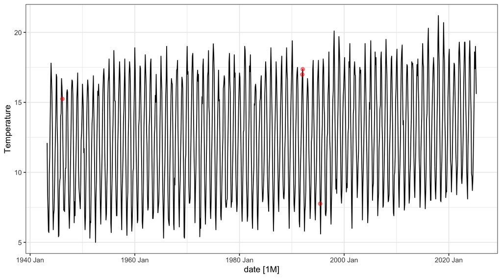

Time plot of Nelson temperatures with interpolated temperature values for missing dates, interpolated temperature values, denoted as red points.

```r
train_filled %>% autoplot(Temperature) + geom_point(data = vals, aes(x = date, y = Temperature, label = Temperature), inherit.aes = FALSE, colour = "red", alpha = 0.5, size = 2) + theme_bw()
```

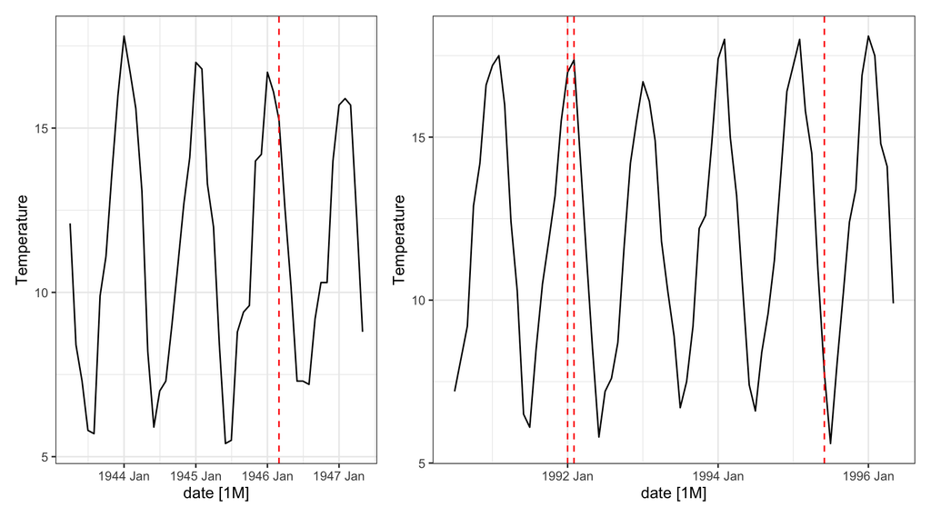

Subseries time plots of Nelson temperatures around interpolated temperature values, denoted as red dashed vertical lines. All interpolated values appear to be reasonable estimates and there no visually obvious unusual behaviour.

```r
plt46 <- train_filled %>%
  filter(date < yearmonth("1947 Jun")) %>%
  autoplot(Temperature) +
    geom_vline(xintercept = yearmonth("1946 Mar"),
               colour = "red", linetype = "dashed") +
    theme_bw()

plt9x <- train_filled %>%
  filter(date > yearmonth("1990 Jun") & date < yearmonth("1996 Jun")) %>%
  autoplot(Temperature) +
    geom_vline(xintercept = yearmonth("1992 Jan"),
               colour = "red", linetype = "dashed") +
    geom_vline(xintercept = yearmonth("1992 Feb"),
               colour = "red", linetype = "dashed") +
    geom_vline(xintercept = yearmonth("1995 Jun"),
               colour = "red", linetype = "dashed") +
    theme_bw()



plt46 + plt9x + plot_layout(widths = c(2, 3))
```

## 1.4 Visualisation and Feature Discussion

Contributors: Joshua Buchanan

The ACF confirms strong positive autocorrelation at lags of 12, 24, and 36 months and strong negative autocorrelation at lags of 6, 18, and 30 months, consistent with the annual seasonal cycle, while the PACF shows significant spikes across the first 12 lags suggesting a complex short-term autocorrelation structure that will need to be accounted for in both the ARIMA and dynamic regression models.

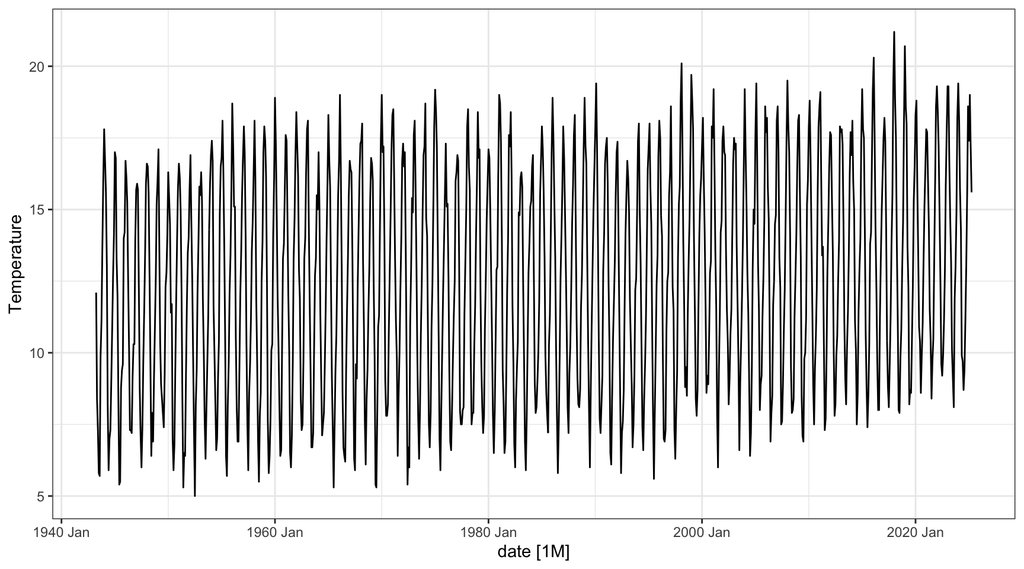

```r
# Time plot
train_filled %>%
  autoplot(Temperature) +
  theme_bw()
```

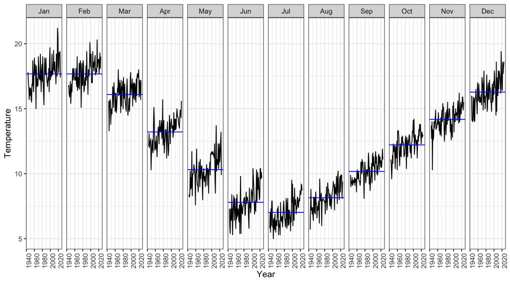

```r
train_filled %>%
  gg_subseries() +
  labs(x = "Year") +
  theme_bw() +
  theme(axis.text.x = element_text(angle = 90))
```

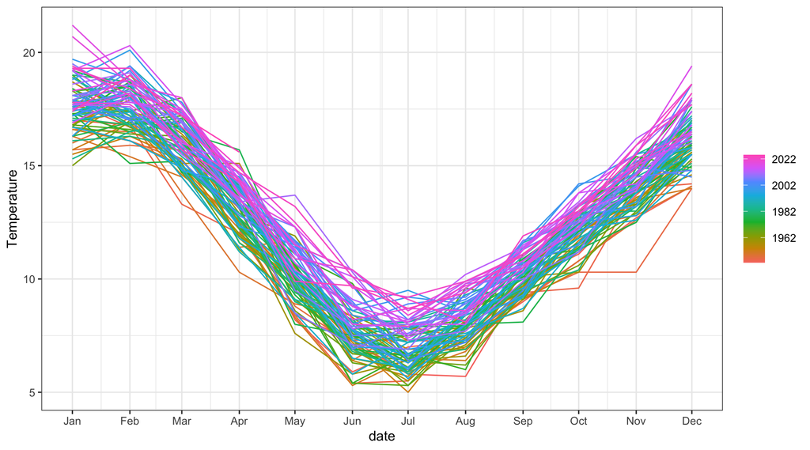

```r
# Seasonality plot
train_filled %>%
  gg_season(Temperature) +
  theme_bw()
```

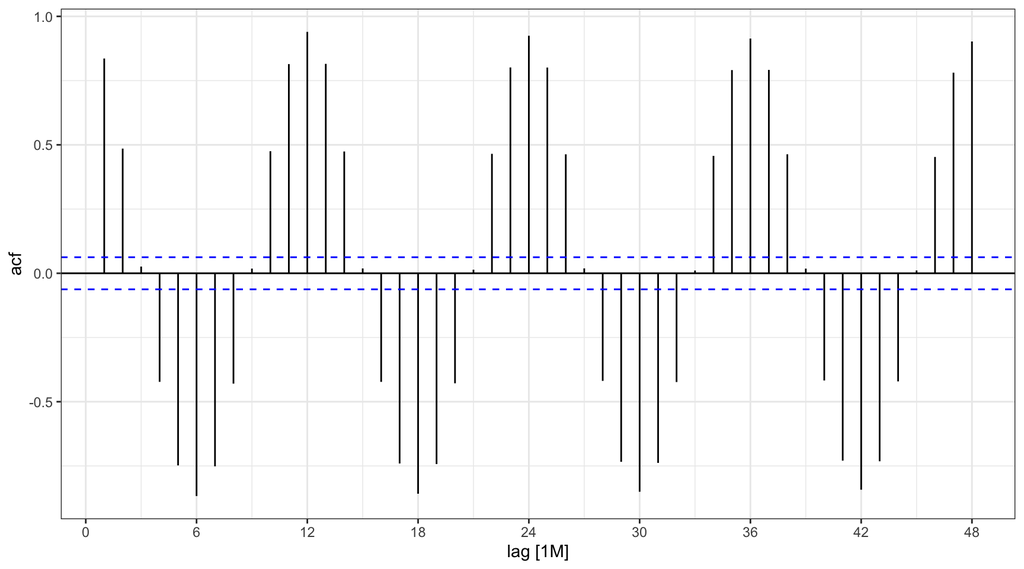

```r
# ACF plot
train_filled %>%
  ACF(Temperature, lag_max=48) %>%
  autoplot() +
  theme_bw()
```

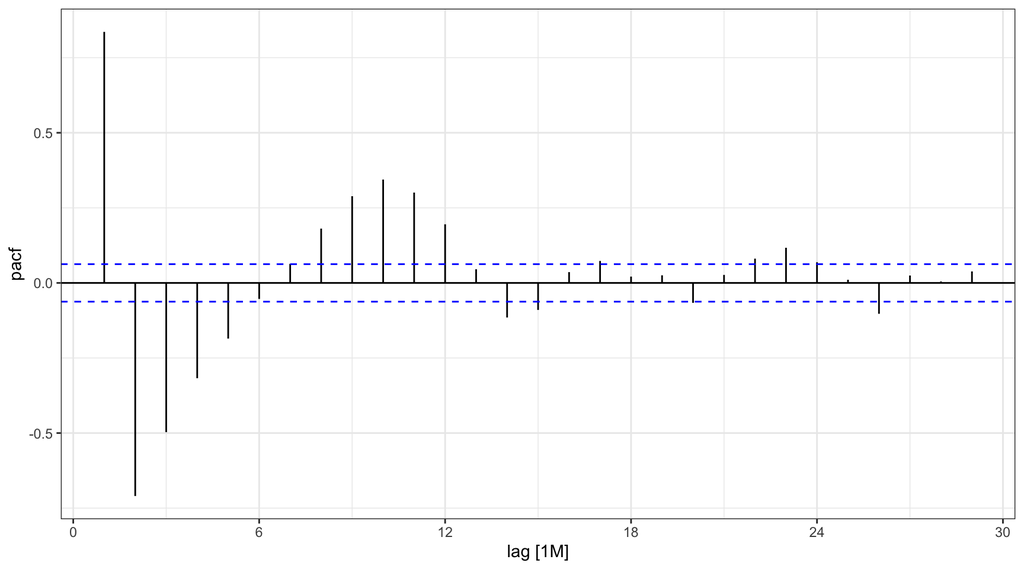

```r
# PACF plot
train_filled %>%
  PACF(Temperature, lag.max=48) %>%
  autoplot() +
  theme_bw()
```

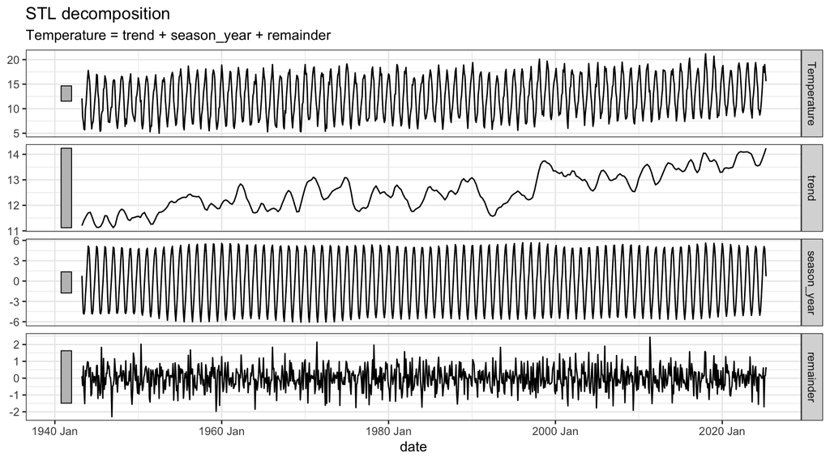

```r
# STL decomp
train_filled %>%
  model(STL(Temperature ~ trend(window=21))) %>%
  components() %>%
  autoplot() +
  theme_bw()
```

# 2 ETS Models

## 2.1 Model Exploration and Shortlisting

Contributors: Xinyi Kong

**Methodology:**

The STL decomposition and ACF plot together provide strong evidence of both a clear seasonal pattern and a long-term trend in the temperature data. Additionally, the time series displays strong, consistent seasonality with temperatures peaking in January (summer, ~17–18°C) and reaching a trough in July (winter, ~6–7°C), and the STL decomposition confirms the seasonality is additive. Apart from that, the trend component from the STL decomposition reveals a positive trend, rising from approximately 11°C in the early 1940s to around 14°C by the mid-2020s.

As we discussed above, candidate ETS models were selected based on strong annual seasonality, a slowly evolving trend, and approximately constant variance over time. These features suggest that additive error and additive seasonal structures are appropriate for this data set. Therefore, the manually selected ETS models include:

### 2.1.1 ETS model equations

#### ETS(AAA):

**Observation equation:**
$$y_t = \ell_{t-1} + b_{t-1} + s_{t-m} +
\epsilon_t$$

**Level equation:**
$$\ell_t
= \ell_{t-1} + b_{t-1} + \alpha \epsilon_t$$

**Trend equation:**
$$b_t =
b_{t-1} + \beta \epsilon_t$$

**Seasonal equation:**
$$s_t
= s_{t-m} + \gamma \epsilon_t$$
Where:

- $\ell_t$ = level at time $t$
- $b_t$ = trend (slope) at time $t$
- $s_t$ = seasonal component at time $t$
- $m$ = seasonal period ($m = 12$ for monthly data)
- $\alpha \in [0,1]$ = smoothing parameter for the level
- $\beta \in [0,1]$ = smoothing parameter for the trend
- $\gamma \in [0,1]$ = smoothing parameter for the seasonal component
- $\epsilon_t \sim \text{NID}(0, \sigma^2)$ = white noise error term

#### ETS(ANA):

**Observation equation:**
$$y_t = \ell_{t-1} + s_{t-m} +
\epsilon_t$$

**Level equation:**
$$\ell_t
= \ell_{t-1} + \alpha \epsilon_t$$

**Seasonal equation:**
$$s_t
= s_{t-m} + \gamma \epsilon_t$$

Where:

- $\ell_t$ = level at time $t$
- $s_t$ = seasonal component at time $t$
- $m$ = seasonal period ($m = 12$ for monthly data)
- $\alpha \in [0,1]$ = smoothing parameter for the level
- $\gamma \in [0,1]$ = smoothing parameter for the seasonal component
- $\epsilon_t \sim \text{NID}(0, \sigma^2)$ = white noise error term

#### ETS(AAdA):

**Observation equation:**
$$y_t = \ell_{t-1} + \phi b_{t-1} + s_{t-m} +
\epsilon_t$$
**Level equation:**
$$\ell_t = \ell_{t-1} + \phi b_{t-1} + \alpha
\epsilon_t$$

**Trend equation:**
$$b_t =
\phi b_{t-1} + \beta \epsilon_t$$

**Seasonal equation:**
$$s_t
= s_{t-m} + \gamma \epsilon_t$$

Where:

- $\ell_t$ = level at time $t$
- $b_t$ = trend (slope) at time $t$
- $s_t$ = seasonal component at time $t$
- $m$ = seasonal period ($m = 12$ for monthly data)
- $\phi \in [0,1]$ = damping parameter
- $\alpha \in [0,1]$ = smoothing parameter for the level
- $\beta \in [0,1]$ = smoothing parameter for the trend
- $\gamma \in [0,1]$ = smoothing parameter for the seasonal component
- $\epsilon_t \sim \text{NID}(0, \sigma^2)$ = white noise error term

### Multiplicative models:

#### ETS(M,A,M):

**Observation equation:**
$$y_t = (\ell_{t-1} + b_{t-1}) \cdot s_{t-m} \cdot
(1 + \epsilon_t)$$

**Level equation:**
$$\ell_t
= (\ell_{t-1} + b_{t-1}) \cdot (1 + \alpha \epsilon_t)$$

**Trend equation:**
$$b_t =
b_{t-1} + \beta(\ell_{t-1} + b_{t-1}) \cdot \epsilon_t$$

**Seasonal equation:**
$$s_t
= s_{t-m} \cdot (1 + \gamma \epsilon_t)$$

Where:

- $\ell_t$ = level at time $t$
- $b_t$ = trend (slope) at time $t$
- $s_t$ = seasonal component at time $t$
- $m$ = seasonal period ($m = 12$ for monthly data)
- $\alpha \in [0,1]$ = smoothing parameter for the level
- $\beta \in [0,1]$ = smoothing parameter for the trend
- $\gamma \in [0,1]$ = smoothing parameter for the seasonal component
- $\epsilon_t \sim \text{NID}(0, \sigma^2)$ = white noise error term

#### ETS(M,Ad,M):

**Observation equation:**
$$y_t = (\ell_{t-1} + \phi b_{t-1}) \cdot s_{t-m}
\cdot (1 + \epsilon_t)$$

**Level equation:**
$$\ell_t
= (\ell_{t-1} + \phi b_{t-1}) \cdot (1 + \alpha \epsilon_t)$$

**Trend equation:**
$$b_t =
\phi b_{t-1} + \beta(\ell_{t-1} + \phi b_{t-1}) \cdot
\epsilon_t$$

**Seasonal equation:**
$$s_t
= s_{t-m} \cdot (1 + \gamma \epsilon_t)$$

Where:

- $\ell_t$ = level at time $t$
- $b_t$ = trend (slope) at time $t$
- $s_t$ = seasonal component at time $t$
- $m$ = seasonal period ($m = 12$ for monthly data)
- $\phi \in [0,1]$ = damping parameter
- $\alpha \in [0,1]$ = smoothing parameter for the level
- $\beta \in [0,1]$ = smoothing parameter for the trend
- $\gamma \in [0,1]$ = smoothing parameter for the seasonal component
- $\epsilon_t \sim \text{NID}(0, \sigma^2)$ = white noise error term

Given these features, additive error and additive seasonal structures were considered the primary modelling choice. The initial shortlist focused on ETS models with additive seasonality, including AAA, ANA, AAdA.

In addition, multiplicative specifications were included as benchmark models to assess whether a proportional error and seasonal structure could provide improved fit. These include: ETS(M, A, M); ETS(M, Ad, M). These methods can be used because our data is positive.

Besides, an automatic ETS model was also fitted using ETS(Temperature), which selects the optimal combination of error, trend, and seasonal components by minimising AICc over all possible ETS specifications.

```r
ETS_fit = train_filled %>%
  model(additive = ETS(Temperature ~ error("A") + trend("A") + season("A")),
        ANA = ETS(Temperature ~ error("A") + trend("N") + season("A")),
        AAdA = ETS(Temperature ~ error("A") + trend("Ad") + season("A")),
        multiplicative = ETS(Temperature ~ error("M") + trend("A") + season("M")),
        hw = ETS(Temperature ~ error("M") + trend("Ad") + season("M")))
```

```r
# Automatically fitted ETS model
auto_fit = train_filled %>%
  model(ETS(Temperature))
report(auto_fit)
```

```
## Series: Temperature
## Model: ETS(A,Ad,A)
##   Smoothing parameters:
##     alpha = 0.130333
##     beta  = 0.0001008877
##     gamma = 0.0001002063
##     phi   = 0.9768198
##
##   Initial states:
##      l[0]        b[0]     s[0]    s[-1]   s[-2]    s[-3]    s[-4]      s[-5]
##  11.79101 0.001269328 3.508152 5.108322 5.10655 3.708599 1.601193 -0.3392268
##      s[-6]     s[-7]     s[-8]    s[-9]    s[-10]    s[-11]
##  -2.373887 -4.393807 -5.544025 -4.77372 -2.244295 0.6361458
##
##   sigma^2:  0.7227
##
##      AIC     AICc      BIC
## 6488.256 6488.965 6576.324
```

```r
# Model comparison (e.g. AICc, BIC, accuracy)
glance(ETS_fit) %>% arrange(AICc)
```

| .model | sigma2 | log_lik | AIC | AICc | BIC | MSE | AMSE | MAE |
| --- | --- | --- | --- | --- | --- | --- | --- | --- |
| AAdA | 0.722731177 | -3226.128 | 6488.256 | 6488.965 | 6576.324 | 0.7102576 | 0.7390884 | 0.67166444 |
| additive | 0.731632834 | -3232.666 | 6499.331 | 6499.964 | 6582.506 | 0.7197484 | 0.7499907 | 0.67442053 |
| ANA | 0.733757060 | -3235.109 | 6500.218 | 6500.713 | 6573.608 | 0.7233280 | 0.7473200 | 0.67886184 |
| multiplicative | 0.006605789 | -3359.732 | 6753.465 | 6754.097 | 6836.639 | 0.7721976 | 0.7941468 | 0.06085694 |
| hw | 0.006636320 | -3359.089 | 6754.179 | 6754.887 | 6842.246 | 0.7665507 | 0.7916332 | 0.06103117 |

## 2.2 Selected Model and Justification

Contributors: Xinyi Kong

**Selected model:**

Based on AICc, the ETS(A,Ad,A) model is selected as the preferred model, achieving the lowest AICc among all candidate models. This result is also consistent with the time series diagnostics, as the damped trend specification appropriately reflects the gradually increasing but slowly evolving trend identified in the STL decomposition, while the additive seasonal component captures the stable annual cycle. The damped trend is preferred over the full additive trend (AAA) as it avoids over-forecasting by allowing the trend to flatten over the forecast horizon.

```r
# Selected ETS model
ETS_final = train_filled %>%
  mutate(Temperature = na_seadec(Temperature)) %>%
  model(AAdA = ETS(Temperature ~ error("A") + trend("Ad") + season("A")))
report(ETS_final)
```

```
## Series: Temperature
## Model: ETS(A,Ad,A)
##   Smoothing parameters:
##     alpha = 0.130333
##     beta  = 0.0001008877
##     gamma = 0.0001002063
##     phi   = 0.9768198
##
##   Initial states:
##      l[0]        b[0]     s[0]    s[-1]   s[-2]    s[-3]    s[-4]      s[-5]
##  11.79101 0.001269328 3.508152 5.108322 5.10655 3.708599 1.601193 -0.3392268
##      s[-6]     s[-7]     s[-8]    s[-9]    s[-10]    s[-11]
##  -2.373887 -4.393807 -5.544025 -4.77372 -2.244295 0.6361458
##
##   sigma^2:  0.7227
##
##      AIC     AICc      BIC
## 6488.256 6488.965 6576.324
```

## 2.3 Model Equations

Contributors: Xinyi Kong

- **Measurement equation:**
  $$y_t = \ell_{t-1} + \phi b_{t-1} + s_{t-m} +
  \epsilon_t$$
- **State equations:**
  $$\ell_t = \ell_{t-1} + \phi b_{t-1} + \alpha
  \epsilon_t$$
  $$b_t = \phi b_{t-1} +
  \beta \epsilon_t$$
  $$s_t = s_{t-m} +
  \gamma \epsilon_t$$
- **Parameter estimates:**

$$\alpha = 0.130333 \quad \beta = 0.0001008877 \quad \gamma =
0.0001002063 , \quad \phi = 0.9768198 \quad\sigma^2 = 0.7227$$

# 3 ARIMA Models

## 3.1 Transformations and Differencing

Contributors: Bea Cooke

**Transformations:**

The time plot shows no visual evidence of multiplicative seasonality, as seasonal fluctuations appear approximately constant and do not appear to depend on the level of the series. Additionally, the selected Box-Cox parameter, $\lambda = 0.92$, is sufficiently close to $1$. Given no visual evidence and $\lambda \approx 1$, no transformation is used.

**Differencing:**

The series is non-stationary, showing both additive seasonality and increasing trend. This is supported by the KPSS test, which produced a p-value of 0.01, suggesting that we reject the null hypothesis (i.e. reject stationarity). Differencing is therefore required to induce stationarity prior to fitting candidate ARIMA models. STL seasonal strength was reported as 0.97, suggesting one seasonal difference to be applied to the 12-month seasonal period. On visual inspection of the time plot, the resulting seasonally differenced series appears stationary, resembling a white noise process. The KPSS test of the seasonally differenced series produced a p-value of 0.1, supporting stationarity of the seasonally differenced series.

```r
lambda <- train_filled %>%
  features(Temperature, features = guerrero) %>%
  pull(lambda_guerrero) #box-cox lambda: approx 1 -> no transform

cat("Box-Cox Lambda: ", lambda, sep = "  ")
```

```
## Box-Cox Lambda:   0.9198184
```

```r
strength <- train_filled %>%
  features(Temperature, feat_stl) %>%
  pull(seasonal_strength_year) #STL strength > 0.67 ->  seasonal difference

cat("STL Seasonal Strength: ", strength, sep = "  ")
```

```
## STL Seasonal Strength:   0.968092
```

```r
#check auto selection # seasonal diffs
train_filled %>%
  features(Temperature,
           unitroot_nsdiffs)
```

| nsdiffs |
| --- |
| 1 |

```r
#apply seasonal diff
train_filled %<>% mutate(diff_temp = Temperature %>% difference(12))

#check auto selection num diffs after applying seasonal
train_filled %>%
  features(diff_temp,
           unitroot_ndiffs)
```

| ndiffs |
| --- |
| 0 |

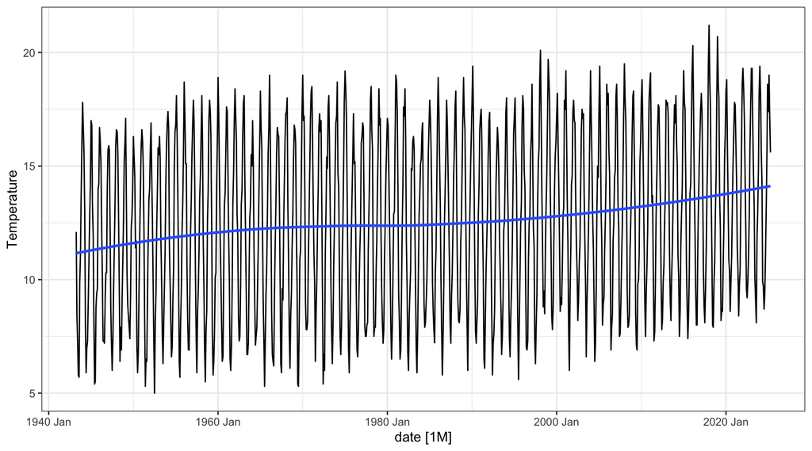

Time plot of the series with strong annual seasonality and weak positive trend.

```r
train_filled %>% autoplot(Temperature) + geom_smooth(se = F) + theme_bw()
```

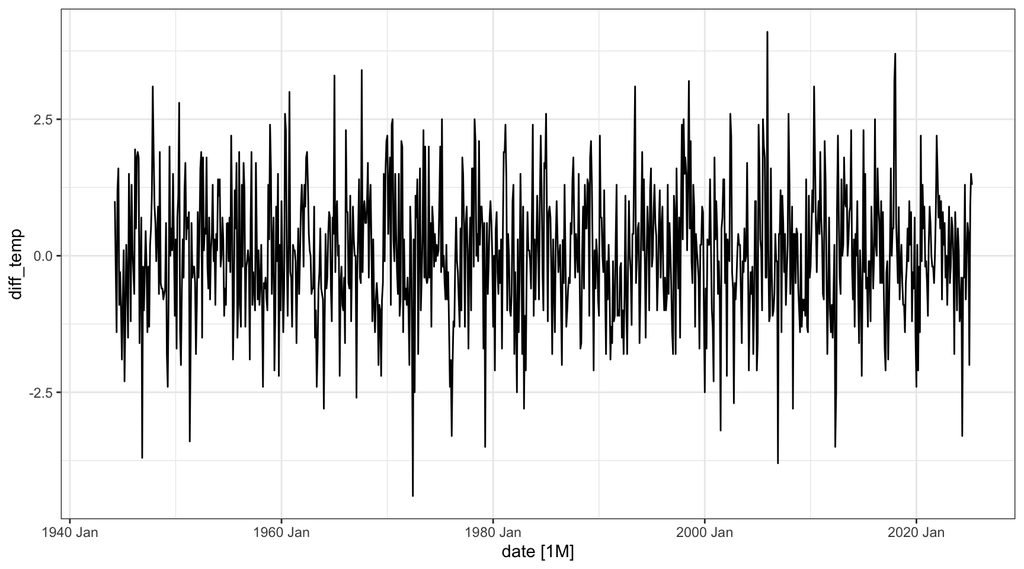

Time plot of the seasonally differenced series, the differenced series resembles a white noise process centered approximately around 0, with no obvious seasonality or trend.

```r
train_filled %>% autoplot(diff_temp) + theme_bw()
```

```r
#KPSS on not differenced , sig p-val -> not stationary
train_filled %>% features(Temperature, unitroot_kpss)
```

| kpss_stat | kpss_pvalue |
| --- | --- |
| 1.627702 | 0.01 |

```r
#KPSS on seasonally differenced, non-sig p-val -> stationary
train_filled %>% features(diff_temp, unitroot_kpss)
```

| kpss_stat | kpss_pvalue |
| --- | --- |
| 0.01192112 | 0.1 |

## 3.2 Model Exploration and Shortlisting

Contributors: Bea Cooke

**Methodology:**

In all manually specified models, the difference terms $d$ and $D$ are chosen to match the differencing outlined above. As no first difference and only one seasonal difference were needed, the non-seasonal term was chosen as $d=0$ and the seasonal term as $D=1$.

Visual inspection of both the ACF and PACF plots of the seasonally differenced series allows assessment of candidate AR/MA parameter values ($p,q, P,Q$). The PACF shows exponential decay in the seasonal lags, whereas the ACF shows a significant spike at lag 12 and no further significant spikes at any other seasonal lag. This pattern suggests a seasonal MA(1) component and no seasonal AR component. Consequently, seasonal terms for all candidate models are $P=0$ and $Q=1$.

The ACF shows additional non-seasonal spikes at lags 1, 3, and 4; however, the spikes at lags 3 and 4 are relatively close to the significance threshold and are of a much smaller magnitude than the spike at lag 1. For this reason both $q=1$ and $q=4$ are considered and we fit both $ARIMA(0,0,1)(0,1,1)_{12}$ and $ARIMA(0,0,4)(0,1,1)_{12}$. In the PACF, there are significant spikes at lags 1 and 3. As with the ACF, the spike at lag 3 is relatively close to the threshold and much smaller than the spike observed at lag 1. So we similarly consider both $p=1$ and $p=3$ and fit both $ARIMA(1,0,0)(0,1,1)_{12}$ and $ARIMA(3,0,0)(0,1,1)_{12}$. Finally, an ARIMA model is fitted automatically for comparison.

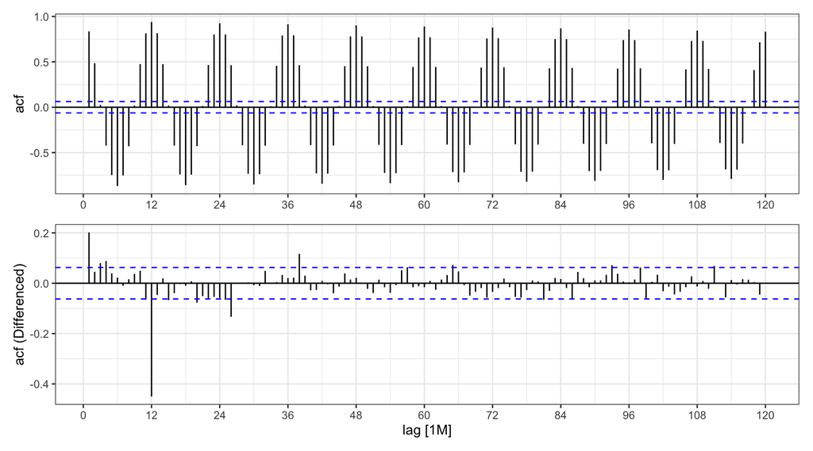

```r
# acf plots on longer lags to see shape
plt_acf <- train_filled %>%
              ACF(Temperature, lag_max=120) %>%
                  autoplot() +
                  scale_x_continuous(breaks = seq(0, 120, by = 12)) +
                  theme_bw() +
                  theme(axis.title.x = element_blank())
plt_acf_diff <- train_filled %>%
                    ACF(diff_temp, lag_max=120) %>%
                        autoplot() +
                        scale_x_continuous(breaks = seq(0, 120, by = 12)) +
                        ylab("acf (Differenced)") +
                        theme_bw()

plt_acf + plt_acf_diff + plot_layout(ncol = 1)
```

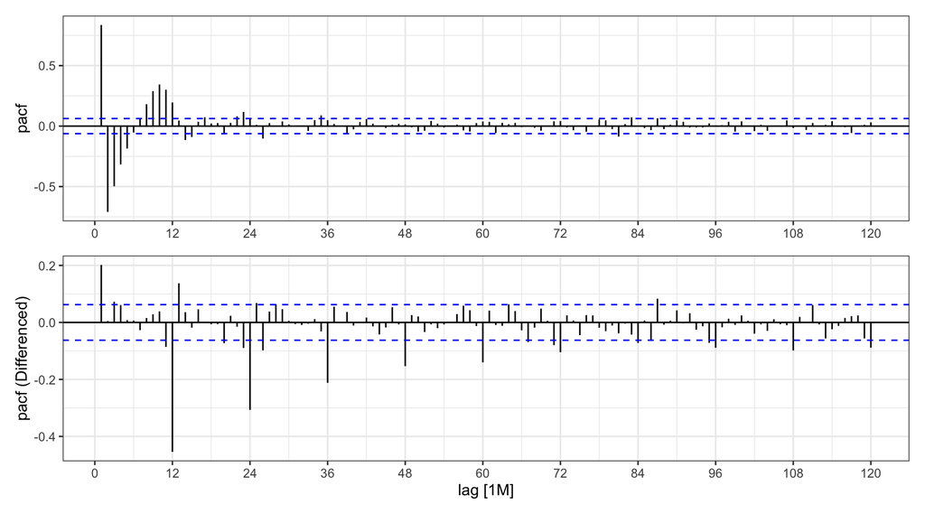

```r
# pacf plots on longer lags to see shape
plt_pacf <- train_filled %>%
              PACF(Temperature, lag_max=120) %>%
                  autoplot() +
                  scale_x_continuous(breaks = seq(0, 120, by = 12)) +
                  theme_bw() +
                  theme(axis.title.x = element_blank())
plt_pacf_diff <- train_filled %>%
                    PACF(diff_temp, lag_max=120) %>%
                          autoplot() +
                          scale_x_continuous(breaks = seq(0, 120, by = 12)) +
                          ylab("pacf (Differenced)") +
                          theme_bw()

plt_pacf + plt_pacf_diff + plot_layout(ncol = 1)
```

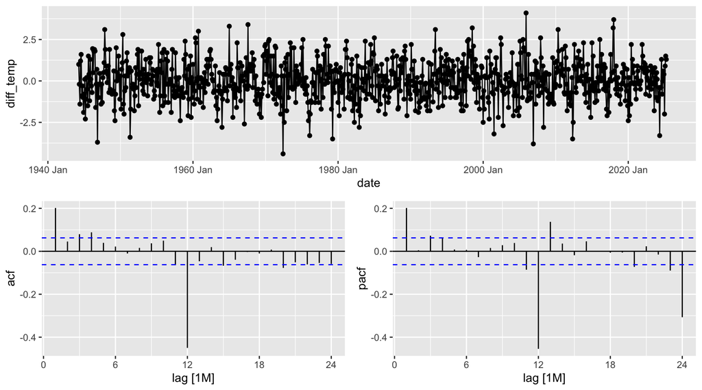

```r
# all together on fewer lags to see significant spikes
train_filled %>% gg_tsdisplay(diff_temp, plot_type = "partial", lag = 24)
```

```r
#fit all models
ARIMA_fits <- train_filled %>%
  model(arima300011 = ARIMA(Temperature ~ pdq(3, 0, 0) + PDQ(0, 1, 1)),
        arima100011 = ARIMA(Temperature ~ pdq(1, 0, 0) + PDQ(0, 1, 1)),
        arima004011 = ARIMA(Temperature ~ pdq(0, 0, 4) + PDQ(0, 1, 1)),
        arima001011 = ARIMA(Temperature ~ pdq(0, 0, 1) + PDQ(0, 1, 1)),
        auto = ARIMA(Temperature))
```

```r
# find best on AICc
report(ARIMA_fits) %>% arrange(AICc) %>% select(.model:BIC)
```

| .model | sigma2 | log_lik | AIC | AICc | BIC |
| --- | --- | --- | --- | --- | --- |
| arima100011 | 0.7722786 | -1262.996 | 2531.993 | 2532.018 | 2546.634 |
| auto | 0.7783413 | -1265.531 | 2541.061 | 2541.124 | 2565.463 |
| arima001011 | 0.7864100 | -1271.150 | 2548.300 | 2548.325 | 2562.941 |
| arima004011 | 0.7898043 | -1263.321 | 7642.638 | 7642.725 | 7671.920 |
| arima300011 | 0.7900245 | -1265.462 | 7644.918 | 7644.980 | 7669.320 |

```r
accuracy(ARIMA_fits) %>%  select(.model, RMSE, MAE, MAPE, MASE) %>% adorn_rounding(digits = 4)
```

| .model | RMSE | MAE | MAPE | MASE |
| --- | --- | --- | --- | --- |
| arima300011 | 0.8816 | 0.6904 | 6.0634 | 0.7446 |
| arima100011 | 0.8725 | 0.6924 | 6.0647 | 0.7468 |
| arima004011 | 0.8810 | 0.6924 | 6.1018 | 0.7468 |
| arima001011 | 0.8805 | 0.6985 | 6.0934 | 0.7534 |
| auto | 0.8750 | 0.6949 | 6.0858 | 0.7495 |

```r
ARIMA_fits %>% select(arima100011) %>% report() #report best
```

```
## Series: Temperature
## Model: ARIMA(1,0,0)(0,1,1)[12]
##
## Coefficients:
##          ar1     sma1
##       0.3107  -0.8822
## s.e.  0.0321   0.0155
##
## sigma^2 estimated as 0.7723:  log likelihood=-1263
## AIC=2531.99   AICc=2532.02   BIC=2546.63
```

## 3.3 Selected Model and Justification

Contributors: Bea Cooke

**Selected model:**

Based on AICc, $ARIMA(1,0,0)(0,1,1)_{12}$ is selected as the model likely to have the best predictive ability. AICc was reported as 2532, this model also yielded the lowest uncorrected AIC (2532) and BIC (2547) further supporting this choice.

```r
#refit selected model
ARIMA_fit <- train_filled %>%
  model(arima100011 = ARIMA(Temperature ~ pdq(1, 0, 0) + PDQ(0, 1, 1)))

#report model coefs
ARIMA_fit %>%
  select(arima100011) %>%
  coefficients() %>% select(.model:std.error) %>%
  mutate(across(where(is.numeric), round, 3))
```

| .model | term | estimate | std.error |
| --- | --- | --- | --- |
| arima100011 | ar1 | 0.311 | 0.032 |
| arima100011 | sma1 | -0.882 | 0.016 |

## 3.4 Model Equation (Backshift Notation)

Contributors: Bea Cooke

$$(1 - 0.311 B)(1 - B^{12}) y_t = (1 - 0.882 B^{12})\varepsilon_t$$

# 4 Dynamic Regression Models

## 4.1 Explanation of Dynamic Regression

Contributors: Joshua Buchanan

At their core, **dynamic regression models** are what you get when standard regression and ARIMA are combined: you get external predictors *and* proper time series error structure in one model.

The three approaches compared:

- **Standard regression** lets you include useful external variables (holidays, economic data etc.) but assumes errors are white noise
- **Pure ARIMA** handles autocorrelation well but you’re stuck with no external predictors, just the series modelling itself
- **Dynamic regression** covers both: $y_t = \beta_0 + \beta_1 x_{1,t} + \cdots + \eta_t$ where the residual $\eta_t$ follows an $\text{ARIMA}(p,d,q)$ process rather than being white noise

One thing worth noting: there are actually **two error terms** in the model. $\eta_t$ is the regression error, and $\varepsilon_t$ is the white noise innovation buried inside the ARIMA: only $\varepsilon_t$ is assumed to be white noise, not $\eta_t$.

The intention is to use dynamic regression when you have predictors that clearly explain some variation in your series, but your residuals are still autocorrelated after fitting.

## 4.2 Model Exploration

Contributors: Joshua Buchanan

**Approach:**

Three predictor types were considered for the dynamic regression models:

- **Linear trend** — included via `trend()` to capture the long-run warming signal in the Nelson temperature series
- **Fourier terms** — used to model seasonality rather than seasonal ARIMA differencing, with $K$ ranging from 1 to 6 (the maximum for monthly data with period 12). Each additional $K$ adds one sine and one cosine pair, allowing progressively more flexible seasonal shapes
- **Intervention variables** — visual inspection of the training data and filtering for extreme values found no obvious spikes or structural breaks, so no dummy variables were included

`PDQ(0,0,0)` was specified to prevent the auto ARIMA from also fitting seasonal ARIMA components on top of the Fourier terms, which would double-handle the seasonality. The $p$, $d$, $q$ orders for the error ARIMA were left to automatic selection in all models.

```r
# Fit dynamic regression models with linear trend and Fourier seasonality
# K = 1 to 6 (maximum for period 12 monthly data)
# PDQ(0,0,0) suppresses seasonal ARIMA to avoid double-handling seasonality with Fourier terms
dynreg_fit <- train_filled %>%
  model(
    K1 = ARIMA(Temperature ~ trend() + fourier(K = 1) + PDQ(0,0,0)),
    K2 = ARIMA(Temperature ~ trend() + fourier(K = 2) + PDQ(0,0,0)),
    K3 = ARIMA(Temperature ~ trend() + fourier(K = 3) + PDQ(0,0,0)),
    K4 = ARIMA(Temperature ~ trend() + fourier(K = 4) + PDQ(0,0,0)),
    K5 = ARIMA(Temperature ~ trend() + fourier(K = 5) + PDQ(0,0,0)),
    K6 = ARIMA(Temperature ~ trend() + fourier(K = 6) + PDQ(0,0,0))
  )
```

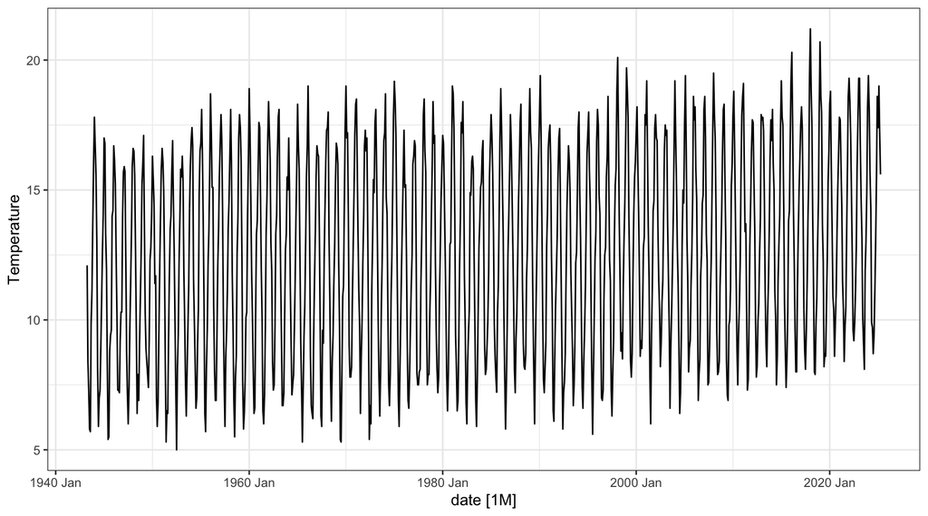

```r
# Visual inspection for outliers or structural breaks before committing to no intervention variables
train_filled %>% autoplot(Temperature) + theme_bw()
```

```r
# Flag minimum and maximum observations as candidate spike dates
train_filled %>%
  filter(Temperature == max(Temperature) | Temperature == min(Temperature))
```

| date | Temperature | diff_temp |
| --- | --- | --- |
| 1952 Jul | 5.0 | -1.5 |
| 2018 Jan | 21.2 | 3.7 |

No extreme values or structural breaks are apparent from the plot or the min/max filter. The series varies smoothly within a consistent seasonal range across the full training period, so no intervention dummy variables were added.

```r
# Compare all K models by information criteria and accuracy
glance(dynreg_fit) %>% arrange(AICc) %>% select(.model, AIC, AICc, BIC)
```

| .model | AIC | AICc | BIC |
| --- | --- | --- | --- |
| K3 | 2435.559 | 2435.880 | 2494.271 |
| K4 | 2438.530 | 2438.963 | 2507.027 |
| K5 | 2440.520 | 2441.082 | 2518.802 |
| K6 | 2442.245 | 2442.878 | 2525.420 |
| K2 | 2448.153 | 2448.379 | 2497.079 |
| K1 | 2608.230 | 2608.415 | 2652.264 |

```r
accuracy(dynreg_fit) %>% select(.model, RMSE, MAE, MASE) %>% adorn_rounding(digits = 4)
```

| .model | RMSE | MAE | MASE |
| --- | --- | --- | --- |
| K1 | 0.9011 | 0.7173 | 0.7737 |
| K2 | 0.8299 | 0.6616 | 0.7136 |
| K3 | 0.8229 | 0.6573 | 0.7089 |
| K4 | 0.8225 | 0.6564 | 0.7080 |
| K5 | 0.8216 | 0.6552 | 0.7067 |
| K6 | 0.8215 | 0.6554 | 0.7069 |

The information criteria show a clear and consistent pattern.

K3 achieves the lowest AICc (2435.880) and BIC (2494.271) of all candidates. K1 is by far the worst, K2 improves substantially, and K3 achieves the best fit. Beyond K3, each additional Fourier pair increases AICc monotonically, indicating the added seasonal flexibility is not justified by the data.

## 4.3 Selected Model and Justification

Contributors: Joshua Buchanan

**K3** is selected as the best dynamic regression model. It includes a linear trend predictor, six Fourier terms (3 sine/cosine pairs) to capture the dominant seasonal harmonics in monthly temperature data, and automatically selected ARIMA(1,0,2) errors. Beyond K3, additional Fourier pairs increase AICc monotonically, meaning the higher-frequency seasonal variation they model is largely noise. K1 and K2 underfit the seasonal structure, as evidenced by the sharp AICc drop from K2 to K3. No intervention variables were included: inspection of the training data revealed no extreme values or structural breaks warranting dummy variables.

```r
# Inspect the automatically selected ARIMA error order for K3
dynreg_fit %>% select(K3) %>% report()
```

```
## Series: Temperature
## Model: LM w/ ARIMA(1,0,2) errors
##
## Coefficients:
##          ar1      ma1      ma2  trend()  fourier(K = 3)C1_12
##       0.9299  -0.6868  -0.1377   0.0022               5.1798
## s.e.  0.0311   0.0454   0.0356   0.0002               0.0421
##       fourier(K = 3)S1_12  fourier(K = 3)C2_12  fourier(K = 3)S2_12
##                    0.5493              -0.1908               0.5043
## s.e.               0.0420               0.0390               0.0391
##       fourier(K = 3)C3_12  fourier(K = 3)S3_12  intercept
##                    0.1477               0.0088    11.5037
## s.e.               0.0361               0.0361     0.1290
##
## sigma^2 estimated as 0.6848:  log likelihood=-1205.78
## AIC=2435.56   AICc=2435.88   BIC=2494.27
```

The fitted K3 model takes the form:

$$\text{Temperature}_t = 11.50 + 0.0022\,t
+ \sum_{k=1}^{3}\left[\alpha_k \cos\!\left(\frac{2\pi k t}{12}\right) +
\beta_k \sin\!\left(\frac{2\pi k t}{12}\right)\right] +
\eta_t$$

where $\eta_t \sim \text{ARIMA}(1,0,2)$. The AR(1) coefficient of 0.930 indicates strong positive autocorrelation in the regression residuals, confirming that a pure regression approach would have been inadequate. The linear trend coefficient (0.0022°C per month) captures the gradual long-run warming signal in the Nelson series.

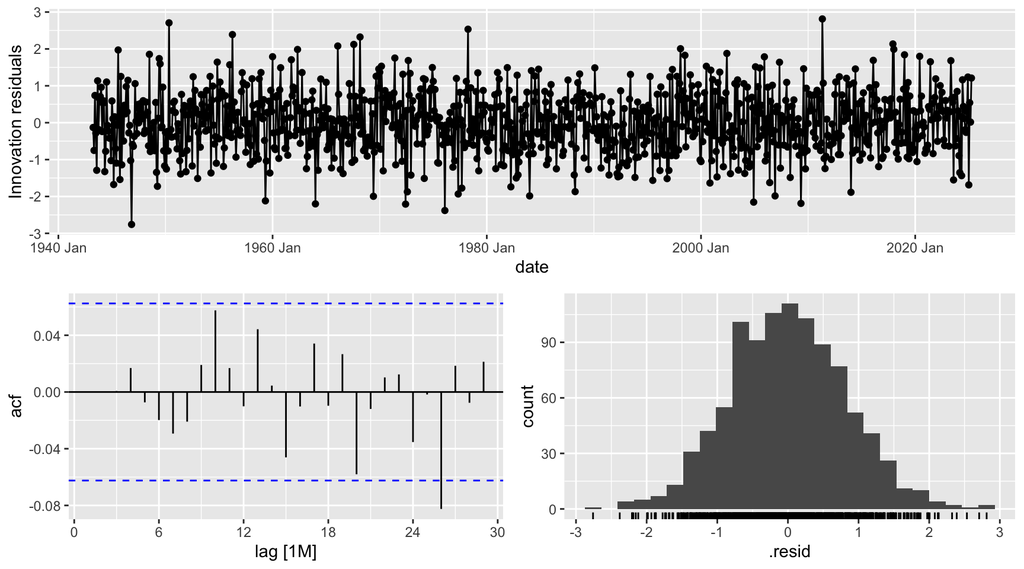

```r
# Residual diagnostics for K3
dynreg_fit %>%
  select(K3) %>%
  gg_tsresiduals()
```

```r
# Ljung-Box test on residuals (lag = 24 for monthly data)
# dof defaults to 0 in fable; to correct for estimated ARIMA(1,0,2) parameters,
# set dof = p + q = 1 + 2 = 3. The default conservative value is used here.
dynreg_fit %>%
  select(K3) %>%
  augment() %>%
  features(.resid, ljung_box, lag = 24)
```

| .model | lb_stat | lb_pvalue |
| --- | --- | --- |
| K3 | 17.3212 | 0.8346432 |

Residual diagnostics support the adequacy of K3. The time plot of residuals shows no obvious structure or trend. The ACF plot shows only one significant spike beyond the confidence bounds, indicating the ARIMA(1,0,2) error structure has absorbed the remaining autocorrelation in the regression residuals. The Ljung-Box test at lag 24 returns a test statistic of 17.32 with a p-value of 0.835, giving no evidence of remaining autocorrelation in the residuals. The model residuals are consistent with white noise.

```r
# Refit K3 as the selected final dynamic regression model
dynreg_final <- train_filled %>%
  model(K3 = ARIMA(Temperature ~ trend() + fourier(K = 3) + PDQ(0,0,0)))
```

## 4.4 Trend Interpretation

Contributors: Joshua Buchanan

The trend coefficient is **0.0022°C per month**.

**95% Confidence Interval:**

$$0.0022 \pm 1.96 \times 0.0002 =
[0.0018,\ 0.0026]$$

This interval sits entirely above zero, meaning we can confidently reject the hypothesis that temperatures are staying constant.

```r
report(dynreg_final)
```

```
## Series: Temperature
## Model: LM w/ ARIMA(1,0,2) errors
##
## Coefficients:
##          ar1      ma1      ma2  trend()  fourier(K = 3)C1_12
##       0.9299  -0.6868  -0.1377   0.0022               5.1798
## s.e.  0.0311   0.0454   0.0356   0.0002               0.0421
##       fourier(K = 3)S1_12  fourier(K = 3)C2_12  fourier(K = 3)S2_12
##                    0.5493              -0.1908               0.5043
## s.e.               0.0420               0.0390               0.0391
##       fourier(K = 3)C3_12  fourier(K = 3)S3_12  intercept
##                    0.1477               0.0088    11.5037
## s.e.               0.0361               0.0361     0.1290
##
## sigma^2 estimated as 0.6848:  log likelihood=-1205.78
## AIC=2435.56   AICc=2435.88   BIC=2494.27
```

# 5 Assumption Checking

## 5.1 Residual Diagnostics

Contributors: Bea Cooke

From the residual diagnostics below, the residuals for all three selected models are approximately centered around 0 and have roughly constant variance. There is possibly a small upward cycle for both the selected ARIMA and Dynamic regression model which peaks slightly before Jan 2000, however visual evidence for this is weak. The residuals for all three models appear approximately normal and are approximately symmetric about 0.

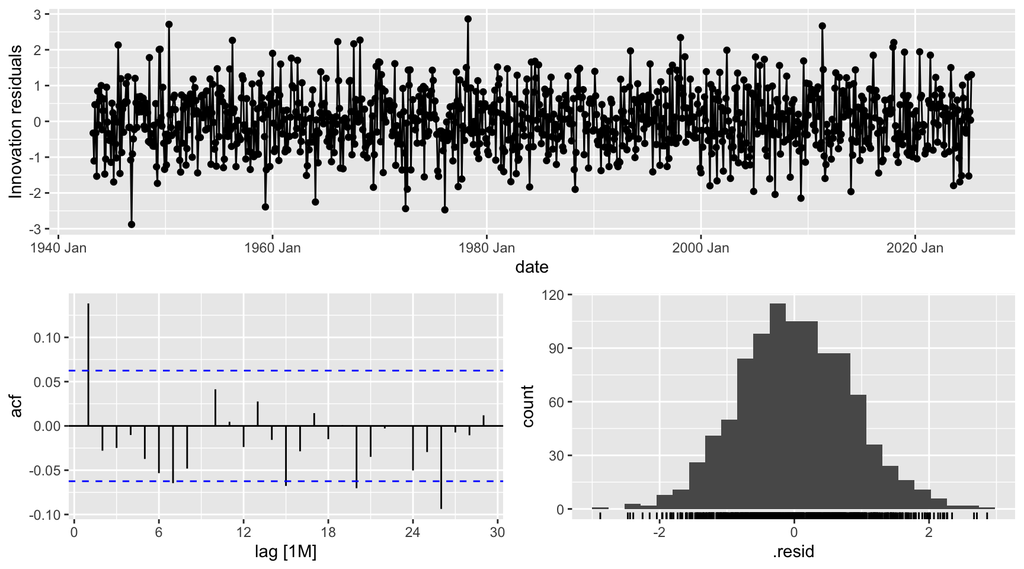

```r
ETS_final %>% gg_tsresiduals()
```

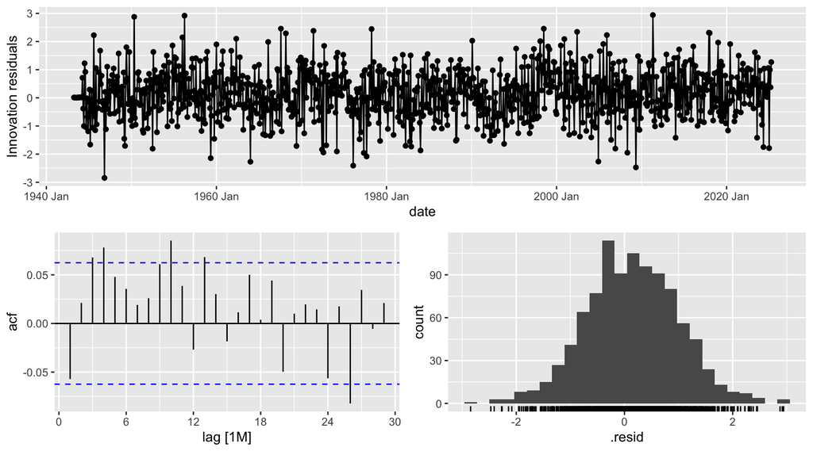

```r
ARIMA_fit %>% gg_tsresiduals()
```

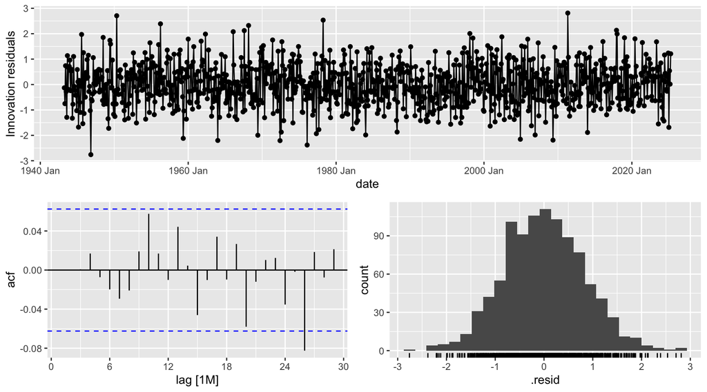

```r
dynreg_final %>%  gg_tsresiduals()
```

## 5.2 Ljung-Box Tests

Contributors: Bea Cooke

Significant p-values we observed in the Ljung-Box tests for both the selected ETS (0.000) and ARIMA (0.001) models meaning we should likely reject the independence assumption, however the observed p-value for the selected dynamic regression model was sufficiently large (0.185) to support independence.

```r
ets_lj <- ETS_final  %>% augment() %>% features(.innov, ljung_box, lag = 24, dof = 18) # ETS - dof & update model
arima_lj <- ARIMA_fit %>% augment() %>% features(.innov, ljung_box, lag = 24, dof = 2) #ARIMA
dyred_lj <- dynreg_final %>% augment() %>% features(.innov, ljung_box, lag = 24, dof = 11) #DyReg - dof


bind_rows(ets_lj, arima_lj, dyred_lj) %>% janitor::adorn_rounding(digits = 3) #print all together
```

| .model | lb_stat | lb_pvalue |
| --- | --- | --- |
| AAdA | 48.992 | 0.000 |
| arima100011 | 48.955 | 0.001 |
| K3 | 17.321 | 0.185 |

## 5.3 Discussion

Contributors: Bea Cooke

For the selected dynamic regression model the residual diagnostic plots and Ljung-Box test provided no evidence that the standard assumptions were violated, and hence this model can be trusted for forecasting.

For the selected ETS and ARIMA models both the ACF plot of the residuals and the Ljung-Box tests results supported the correlated residuals and violation of the independence assumption. Since the independence assumption does not hold there are doubts that these models will provide reliable forecasts and should not be trusted, as our variance estimates used to compute our forecast errors will not be accurate.

# 6 Forecasting

## 6.1 Forecasts (h = 12)

Contributors: Bea Cooke

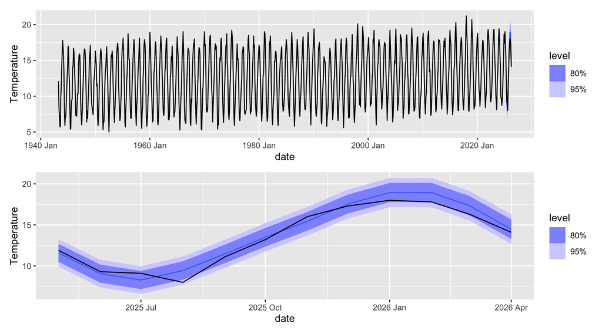

```r
# --- ETS forecast for h = 12 months ---
ETS_fc_final <- ETS_final %>%
  forecast(h = 12)

plt_ets_fc <- autoplot(ETS_fc_final, nelson)
plt_ets_fc_test <- autoplot(ETS_fc_final, test)

plt_ets_fc + plt_ets_fc_test + plot_layout(ncol = 1)
```

```r
# Print point forecasts and 95% intervals
ETS_fc_final %>%
  hilo(level = 95) %>%
  select(date, .mean, `95%`) %>%
  unpack_hilo(cols = `95%`) %>%
  adorn_rounding(digits = 3)
```

| date | .mean | 95%_lower | 95%_upper |
| --- | --- | --- | --- |
| 2025 May | 11.586 | 9.920 | 13.253 |
| 2025 Jun | 9.057 | 7.377 | 10.738 |
| 2025 Jul | 8.287 | 6.593 | 9.981 |
| 2025 Aug | 9.437 | 7.729 | 11.145 |
| 2025 Sep | 11.457 | 9.735 | 13.179 |
| 2025 Oct | 13.492 | 11.756 | 15.228 |
| 2025 Nov | 15.432 | 13.683 | 17.182 |
| 2025 Dec | 17.540 | 15.777 | 19.303 |
| 2026 Jan | 18.938 | 17.161 | 20.714 |
| 2026 Feb | 18.940 | 17.150 | 20.730 |

[output cut: 2 more lines]

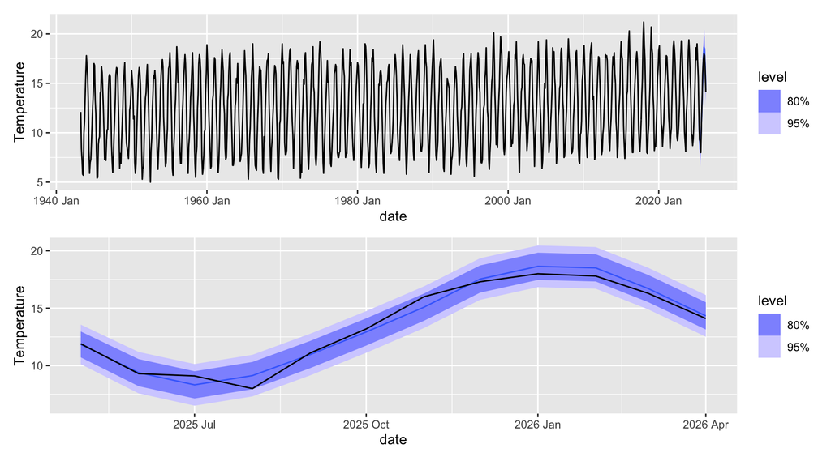

```r
# --- ARIMA forecast for h = 12 months ---
ARIMA_fc <- ARIMA_fit %>% forecast(h = 12)

plt_arima_fc <- autoplot(ARIMA_fc, nelson)
plt_arima_fc_test <-autoplot(ARIMA_fc, test)

plt_arima_fc + plt_arima_fc_test + plot_layout(ncol = 1)
```

```r
# Print point forecasts and 95% intervals
ARIMA_fc %>%
  hilo(level = 95) %>%
  select(date, .mean, `95%`) %>%
  unpack_hilo(cols = `95%`) %>%
  adorn_rounding(digits = 3)
```

| date | .mean | 95%_lower | 95%_upper |
| --- | --- | --- | --- |
| 2025 May | 11.847 | 10.125 | 13.569 |
| 2025 Jun | 9.388 | 7.585 | 11.192 |
| 2025 Jul | 8.324 | 6.513 | 10.136 |
| 2025 Aug | 9.130 | 7.318 | 10.942 |
| 2025 Sep | 10.964 | 9.152 | 12.776 |
| 2025 Oct | 12.932 | 11.120 | 14.744 |
| 2025 Nov | 15.091 | 13.279 | 16.903 |
| 2025 Dec | 17.536 | 15.724 | 19.348 |
| 2026 Jan | 18.645 | 16.833 | 20.458 |
| 2026 Feb | 18.510 | 16.698 | 20.322 |

[output cut: 2 more lines]

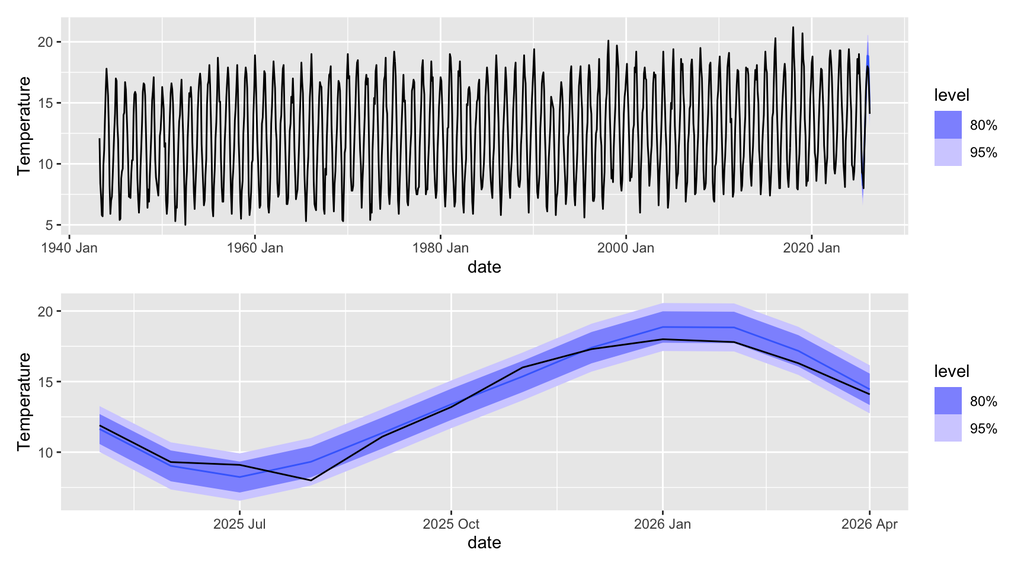

```r
# --- Dynamic regression forecast for h = 12 months ---
# Future data for h=12 forecast horizon
future <- new_data(train_filled, 12)

dynreg_fc <- dynreg_final %>%
  forecast(new_data = future)

# Plot forecast against full nelson series
plt_dyreg_fc <- dynreg_fc %>% autoplot(nelson)
plt_dyreg_fc_test <- dynreg_fc %>% autoplot(test)

plt_dyreg_fc + plt_dyreg_fc_test + plot_layout(ncol = 1)
```

```r
# Print point forecasts and 95% intervals
dynreg_fc %>%
  hilo(level = 95) %>%
  select(date, .mean, `95%`) %>%
  unpack_hilo(cols = `95%`) %>%
  adorn_rounding(digits = 3)
```

| date | .mean | 95%_lower | 95%_upper |
| --- | --- | --- | --- |
| 2025 May | 11.643 | 10.021 | 13.265 |
| 2025 Jun | 9.029 | 7.360 | 10.699 |
| 2025 Jul | 8.239 | 6.564 | 9.914 |
| 2025 Aug | 9.323 | 7.642 | 11.004 |
| 2025 Sep | 11.360 | 9.674 | 13.045 |
| 2025 Oct | 13.391 | 11.702 | 15.080 |
| 2025 Nov | 15.361 | 13.669 | 17.054 |
| 2025 Dec | 17.402 | 15.707 | 19.098 |
| 2026 Jan | 18.865 | 17.167 | 20.563 |
| 2026 Feb | 18.836 | 17.136 | 20.536 |

[output cut: 2 more lines]

## 6.2 Forecast Error vs Test Set

Contributors: Bea Cooke

```r
ETS <- accuracy(ETS_fc_final, nelson)
AR <- accuracy(ARIMA_fc, nelson)
DR <- accuracy(dynreg_fc, nelson)

bind_rows(ETS, AR, DR) %>% select(.model, RMSE, MAE, MAPE, MASE) %>% adorn_rounding(digits = 4)
```

| .model | RMSE | MAE | MAPE | MASE |
| --- | --- | --- | --- | --- |
| AAdA | 0.7566 | 0.6456 | 5.2585 | 0.6585 |
| arima100011 | 0.5781 | 0.4667 | 3.8430 | 0.4760 |
| K3 | 0.6988 | 0.5857 | 4.8259 | 0.5974 |

## 6.3 Discussion

Contributors: Bea Cooke

Comparing the forecast results for all three models to the test set, the observed values fell withing the 95% confidence bounds for all three selected models. For all accuracy reported metrics (RMSE, MAE, MAPE and MASE) the ARIMA model preformed the best (RMSE: 0.5781, MAE: 0.4667, MAPE: 3.8430, MASE: 0.4760), followed by the dynamic regression model (RMSE: 0.6988, MAE: 0.5857, MAPE: 4.8259, MASE: 0.5974) with the ETS model preforming the worst (RMSE: 0.7566, MAE: 0.6456, MAPE: 5.2585, MASE: 0.6585).

# 7 LLMs in Time Series Analysis

## 7.1 LLM Point Forecast

Contributors: Joshua Buchanan (Initial prompt)

### 7.1.1 LLM Prompt and Response

The following prompt was submitted to **Claude (Sonnet 4.5, claude.ai)** on 26 May 2026:

> *“What is your point forecast for the average monthly temperature in Nelson, New Zealand in May 2026? Please explain your reasoning and how you arrived at that number.”*

**Claude’s response:**

> I don’t have access to real-time weather data or the ability to run time series models, so I can’t produce a formal point forecast. But I can reason through this transparently.

> **What I know from general knowledge:** Nelson, NZ is at roughly 41°S. May is mid-autumn in the Southern Hemisphere. Based on historical climate normals, Nelson’s mean temperature in May is approximately 11–12°C. Nelson is one of the sunniest and warmest cities in NZ, with relatively mild autumns.

> **How I’d arrive at a point forecast:**

> A reasonable naive approach would be:
> - **Climatological mean** — the long-run average for May in Nelson is around 11–12°C (based on NIWA climate normals). This is the simplest and often hard-to-beat baseline.
> - **Recent trend adjustment** — global and NZ temperatures have been trending slightly upward over decades. This might nudge the estimate up marginally, perhaps ~0.2–0.5°C above the long-run mean.
> - **ENSO state** — La Niña/El Niño conditions influence NZ temperatures. I don’t have confirmed knowledge of the ENSO state in early 2026, so I can’t apply this adjustment reliably.

> **My point forecast: ~12°C**

> This is essentially the climatological mean with a small upward nudge for the warming trend. I’d attach wide uncertainty to it — a 90% prediction interval might span something like 9–15°C given month-to-month variability.

> If you have access to the actual Nelson temperature series, a model like SARIMA or ETS fitted to that data would give a much more principled forecast than this.

**Follow-up prompt:**

> *“How confident are you in this estimate, and what are the limitations of your approach?”*

**Claude’s response:**

> **Confidence and Limitations**

> **Confidence**

> Low to moderate. I would not stake much on the specific number beyond it being a plausible order-of-magnitude estimate. The ~12°C figure is essentially a climatological mean with a qualitative adjustment — it is not a model output.

> **Limitations**
> - **No fitted model.** I did not fit any time series model (e.g. SARIMA, ETS, or similar) to the actual Nelson temperature record. A proper forecast would estimate trend, seasonality, and residual structure from data.
> - **Climatological figures are from memory.** The 11–12°C baseline comes from my general training knowledge, not from querying NIWA or any authoritative source directly. These figures could be slightly off.
> - **No ENSO adjustment.** ENSO state materially affects NZ temperatures. Without knowing the confirmed ENSO phase for early 2026, this source of interannual variability is unaccounted for.
> - **No recent data.** I have no access to the most recent observed temperatures leading into May 2026, which would be the most informative input for a short-range forecast.
> - **Uncertainty interval is approximate.** The 9–15°C prediction interval was not derived statistically — it is a rough heuristic based on typical seasonal variability.

> **Bottom line**

> The forecast is best interpreted as “May in Nelson is typically around 12°C and there is no strong reason to expect a dramatic departure.” It should not be treated as a calibrated probabilistic forecast.

```r
# extend the other models to May 2026 and compare
bind_rows(
  ETS_final %>%
    forecast(h = 13) %>%
    tail(1) %>%
    as_tibble() %>%
    mutate(Model = "ETS"),

  ARIMA_fit %>%
    forecast(h = 13) %>%
    tail(1) %>%
    as_tibble() %>%
    mutate(Model = "ARIMA"),

  dynreg_final %>%
    forecast(new_data = new_data(train_filled, 13)) %>%
    tail(1) %>%
    as_tibble() %>%
    mutate(Model = "Dynamic")
) %>%
  select(Model, date, .mean)
```

| Model | date | .mean |
| --- | --- | --- |
| ETS | 2026 May | 11.58726 |
| ARIMA | 2026 May | 11.45275 |
| Dynamic | 2026 May | 11.41000 |

**Comparison and comments:** The ETS, ARIMA and Dynamic Regression models produced very similar point forecasts for May 2026, ranging from 11.41°C to 11.59°C. The maximum difference between the statistical models was less than 0.2°C, suggesting strong agreement despite the different modelling approaches.

In comparison, Claude produced a point forecast of 12.0°C, which was approximately 0.4–0.6°C higher than the statistical forecasts. Claude explained that its estimate was based on general climate knowledge and a small adjustment for long-term warming trends rather than a fitted time series model.

An interesting finding is that the LLM forecast remained reasonably close to the statistical forecasts despite not having access to the underlying data. However, the statistical models are more defensible because they were fitted directly to the historical Nelson temperature series and therefore incorporated the observed trend and seasonal patterns. This highlights that LLMs can provide plausible baseline forecasts, but dedicated forecasting models remain more appropriate for quantitative time series prediction.

*Report compiled using R 4.5.1 and fpp3 1.0.3.*